# Conditional Coverage Experiment Summary

## Experiment Goal

Verify the theoretical proposition that CKME-CP achieves **asymptotic conditional coverage**:

```
Cov_n(x) = P(Y_new ∈ C_{n,1-α}(x) | X_new = x)  →  1 − α   for a.e. x,  as n → ∞
```

This is strictly stronger than the marginal coverage guarantee of standard split-CP (which only ensures the unconditional P(Y ∈ C(X)) ≥ 1−α).

## Experiment Settings

| Parameter | Value |
| --- | --- |
| Simulators | `exp2`, `nongauss_B2L` |
| n_vals (Stage 1 = Stage 2 sites) | 50, 100, 200, 400, 800 |
| r_0 (Stage 1 reps per site) | 10 |
| r_1 (Stage 2 reps per site) | 10 |
| alpha | 0.1 (target coverage 90%) |
| t_grid_size | 300 |
| Site selection method | mixed (γ=0.7 LHS + 0.3 adaptive) |
| M_eval (eval grid points) | 100 |
| B_test (fresh draws per eval point) | 2000 |
| n_macro | 20 |
| Hyperparameters | CV-tuned per (simulator, n) via two-stage grid search |

### Hyperparameter Search Grid (Two-Stage CV)

**Stage 1** — fix `h = h_default`, search over `(ell_x, lam)`:

| Parameter | Grid |
| --- | --- |
| ell_x | 0.1, 0.5, 1.0, 2.0, 3.0 |
| lam | 1e-4, 1e-3, 1e-2, 1e-1 |
| h (fixed) | 0.2 |

**Stage 2** — fix best `(ell_x, lam)`, search over `h`:

| Parameter | Grid |
| --- | --- |
| h | 0.05, 0.1, 0.2, 0.3, 0.5 |

### Conditional Coverage Estimation (Score-Based)

For each eval point x^(m) and each macrorep: 1. Compute q_hat from Stage 2 CP calibration (score = |F̂(Y|x) − 0.5|) 2. Generate B=2000 fresh Y_b ~ P(·|X=x^(m)) from the true simulator 3. For each Y_b, compute F̂(Y_b|x^(m)) directly using training Y values as indicator knots (mirrors `calibration.py` exactly — no t_grid inversion, no clipping) 4. Estimate: Cov_n(x^(m)) = (1/B) Σ_b 1{|F̂(Y_b|x^(m)) − 0.5| ≤ q_hat}

## Simulators

### exp2 — Gaussian Heteroscedastic

```
Y = f(x) + ε,     ε ~ N(0, σ²(x))
f(x) = exp(x/10) * sin(x),   x ∈ [0, 2π]
σ(x) = 0.01 + 0.2*(x − π)²
```

Key property: σ(x) is **extremely small near x=π** (σ(π) = 0.01) and grows to ~2.0 near x=0 and x=2π. This 200× variation across the domain creates a severe challenge for any method with a **globally fixed bandwidth h**.

### nongauss_B2L — Centered Gamma (Strong Skew)

```
Y = f(x) + G − k*θ(x),   G ~ Gamma(k=2, θ(x))
f(x) = exp(x/10) * sin(x),   x ∈ [0, 2π]
σ_tar(x) = 0.1 + 0.1*(x − π)²,   θ(x) = σ_tar(x) / √2
```

## Results

### Summary Table — MAE-Cov (mean ± SD over 20 macroreps)

**exp2 (Gaussian heteroscedastic)**

| n | MAE-Cov mean | MAE-Cov SD | SupErr mean | SupErr SD |
| --- | --- | --- | --- | --- |
| 50 | 0.0613 | 0.0078 | 0.165 | 0.048 |
| 100 | 0.0550 | 0.0052 | 0.118 | 0.020 |
| 200 | 0.0498 | 0.0051 | 0.107 | 0.015 |
| 400 | 0.0475 | 0.0027 | 0.100 | ≈0 |
| 800 | 0.0467 | 0.0025 | 0.100 | ≈0 |

**nongauss_B2L (Gamma strong skew)**

| n | MAE-Cov mean | MAE-Cov SD | SupErr mean | SupErr SD |
| --- | --- | --- | --- | --- |
| 50 | 0.0569 | 0.0077 | 0.135 | 0.044 |
| 100 | 0.0498 | 0.0053 | 0.111 | 0.023 |
| 200 | 0.0471 | 0.0034 | 0.103 | 0.010 |
| 400 | 0.0470 | 0.0020 | 0.105 | 0.019 |
| 800 | 0.0480 | 0.0017 | 0.097 | 0.003 |

## Key Observation: Coverage Plateau and the h-vs-σ Problem

### What we observe

**Figure 1: Conditional coverage curves x → Cov_n(x)**

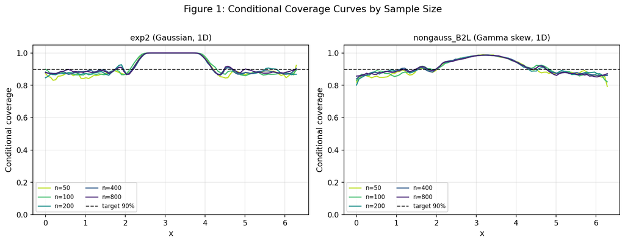

Figure 1: Conditional coverage curves

1. **n=50 → 200**: MAE-Cov decreases for both simulators — consistent with the asymptotic conditional coverage proposition.
2. **n=400 → 800**: MAE-Cov stagnates around 0.047–0.048. The error **does not continue decreasing** with more data. This is a **floor caused by systematic bias, not estimation variance** (SD also stabilizes near zero).
3. **exp2 Figure 1**: The conditional coverage curve x → Cov_n(x) shows a prominent **spike to ≈1.0 in the middle region (x ≈ 2–4, i.e., near π)**. This spike does not shrink as n grows — it is present and equally pronounced for n=400 and n=800.
4. **SupErr for exp2 at n=400/800 = exactly 0.100 with SD≈0**: Every single macrorep achieves the same maximum error, localized at the same x region. This is a deterministic structural failure, not random fluctuation.

### Root cause: globally fixed h vs. locally tiny σ(x)

The nonconformity score is based on F̂(Y|x), estimated with a smooth indicator of bandwidth h. Near x=π, the true noise is σ(π) = 0.01, but the CV-tuned bandwidth h ≈ 0.08–0.2 (tuned to be appropriate over the full domain).

The ratio h/σ(π) ≈ 8–20×: the indicator bandwidth is **far larger than the actual spread of Y|x=π**.

**Consequence:** - For test draws Y_b ~ N(0, 0.01²), all values lie in a tiny range ≈ ±0.03 - The smooth indicator g(Y_b − Y_train) varies negligibly over this range (its scale is h >> σ(π)) - Therefore F̂(Y_b | x=π) ≈ constant ≈ 0.5 for all Y_b - Score_b = |F̂ − 0.5| ≈ 0 << q_hat for all Y_b - **Cov_n(π) → 1.0 regardless of n**

This is confirmed by the quantile estimation diagnostic below: at x=π, the CKME estimated quantile function spans ≈ [−0.25, 0.25] while the true distribution is concentrated in ≈ [−0.03, 0.03]. The CDF estimate is entirely dominated by h, not by the data.

**Figure 2: CKME quantile estimation at three representative x values (exp2)**

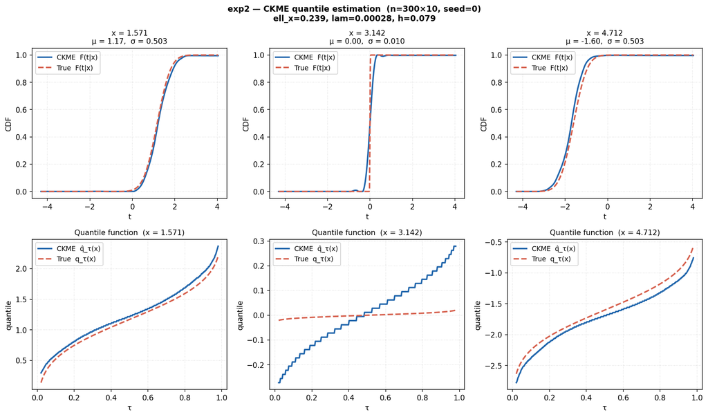

Figure 2: CKME quantile estimation

### Connection to asymptotic theory

The asymptotic conditional coverage proposition requires h → 0 as n → ∞ (or adaptive local bandwidth). With **fixed h**, the CDF estimate at low-noise regions converges to a biased limit, not to the true F(y|x). The systematic over-smoothing at x=π is not reducible by increasing n — it is an O(h) approximation bias that persists in the limit.

This means the plateau in MAE-Cov is **not a failure of the theoretical proposition**, but a consequence of violating its bandwidth assumption.

## exp2 vs nongauss_B2L: Why B2L behaves better

[output not shown]

## Next Steps

- Re-run with larger n_macro (50) on nongauss_B2L to confirm convergence trend
- Try adaptive h(x) = local σ̂(x) * constant for exp2 to see if plateau disappears
- Consider replacing exp2 with a simulator that has moderate heteroscedasticity (e.g., nongauss_A1L or a custom Gaussian with σ variation ≤ 5×)
- Add CQR-style score variant to `run_cond_cov.py` for comparison